# Case Study 4: Take me out to the ball game

Devin W. H.

March 08, 2022

## Background

Utah colleges aren’t particularly known for their MLB players or sucess stories in the country. However, if one had to pursue a future in baseball, which college would provide the most opportunity for a career in MLB? Does BYU have the highest MLB success? Using several datasets, I merged many key data factors together in order to get the necessary information needed to answer this question.

## Data Wrangling

```r
# Merging datasets together, narrowing down to Utah colleges
# Get top salary of each player from each school

data <- People %>%
  left_join(CollegePlaying, by = 'playerID') %>%
  left_join(Schools, by = 'schoolID') %>%
  left_join(Salaries, by = 'playerID') %>%
  filter(state == 'UT') %>%
  select('playerID', 'nameGiven', 'schoolID', 'name_full', 'salary') %>%
  na.omit() %>%
  group_by(playerID, schoolID) %>%
  top_n(1, salary) %>%
  unique()

# We now have all the players from each school with a top salary
```

The next data wrangling code involves getting the average salary from each university and creating a new column where players who played at more than one university were selected to be included in the legend.

```r
# Vector with names of interest
name = c('William Mays', 'Christopher Bob')

# New column that has everyone but the duplicate players in a specific category
data <- data %>%
  mutate(bob = ifelse(nameGiven %in% name, nameGiven, 'Other'))

data2 <- data %>%
  group_by(schoolID) %>%
  mutate(avg_sal = mean(salary)) %>%
  slice(1) %>%
  ungroup() %>%
  select(name_full, avg_sal)
```

## Data Visualization

The first graph below shows individual player salaries from each university. Because two players switched colleges (in no exact order), their key appears in the legend for easier analysis. As evident, BYU has more student data of those getting into MLB while other universities come short. Despite not having as many players, we see that Dixie State College has a relatively successful student in the higher end bracket. The other colleges show very lackluster earnings, showing that they either didn’t get very far ahead or it was simply a temporary position.

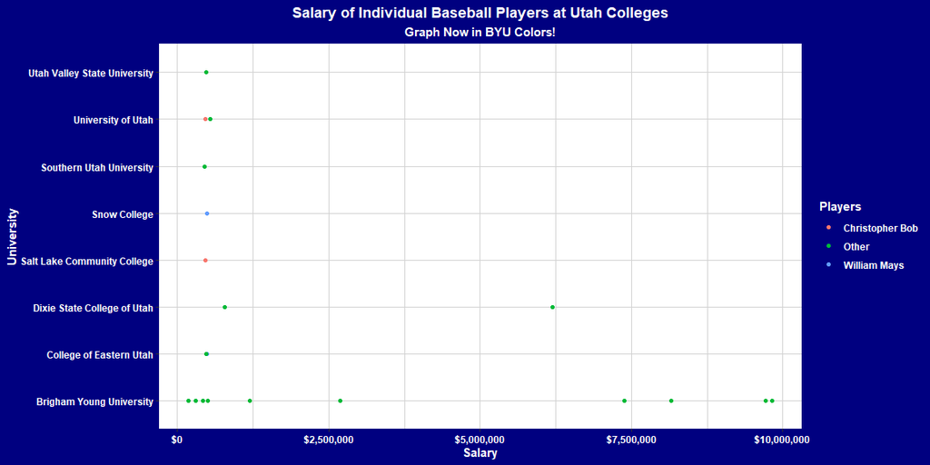

```r
ggplot(data) +
  aes(x = salary, y = name_full, color = bob) +
  geom_point() +
  scale_x_continuous(labels = dollar_format()) +
  labs(x = 'Salary', y = 'University', title = 'Salary of Individual Baseball Players at Utah Colleges', subtitle = 'Graph Now in BYU Colors!', color = 'Players') +
  theme(plot.title = element_text(hjust = 0.5),
        plot.subtitle = element_text(hjust = 0.5, face = 'bold'),
        plot.background = element_rect(fill = 'navyblue', color = 'navyblue'),
        title = element_text(color = 'white', face = 'bold'),
        axis.text = element_text(color = 'white', face = 'bold'),
        panel.grid.major = element_line(color = 'lightgray'),
        panel.grid.minor = element_line(color = 'lightgray'),
        panel.background = element_rect(fill = 'white'),
        legend.background = element_rect(fill = 'navyblue'),
        legend.key = element_rect(fill = 'navyblue'),
        legend.text = element_text(color = 'white', face = 'bold'))
```

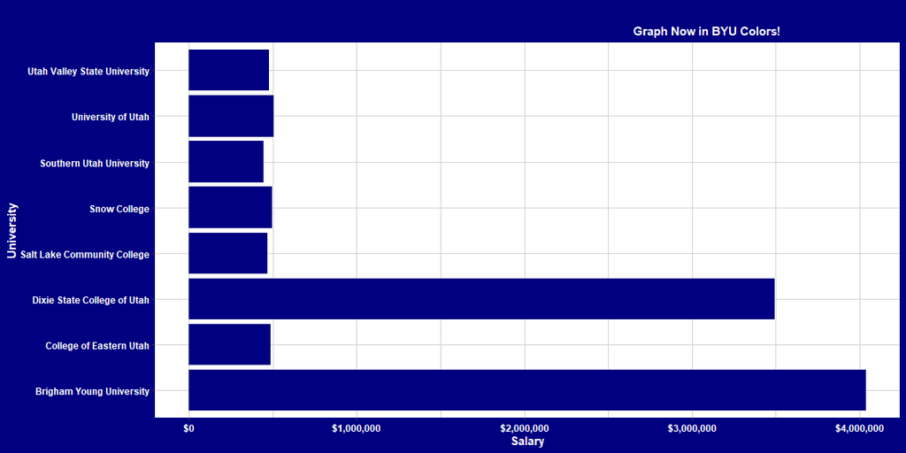

```r
ggplot(data2) +
  aes(x = avg_sal, y = name_full) +
  geom_col(fill = 'navyblue') +
  scale_x_continuous(labels = dollar_format()) +
  labs(x = 'Salary', y = 'University', title = 'Average Salary of Utah College Baseball Players', subtitle = 'Graph Now in BYU Colors!') +
  theme(plot.title = element_text(hjust = -2.5),
        plot.subtitle = element_text(hjust = 0.8, face = 'bold'),
        plot.background = element_rect(fill = 'navyblue', color = 'navyblue'),
        title = element_text(color = 'white', face = 'bold'),
        axis.text = element_text(color = 'white', face = 'bold'),
        panel.grid.major = element_line(color = 'lightgray'),
        panel.grid.minor = element_line(color = 'lightgray'),
        panel.background = element_rect(fill = 'white'))
```

## Conclusions

Based on the two graphs, we prove that BYU has better MLB success. However, these results should be tongue in cheek considering it is unknown what would be of the other universities if they had the same amount of students go onto the major leagues. However, it could also just be that the MLB prefers BYU students in the end.